# Data Visualization Final Exam

Kelin Pan  
October 8, 2018

# Title: BAN 6035: Data Visualization Final Exam

# Date: "October 8, 2018"

# YOUR NAME: Kelin Pan

# The script to load the packages and import the data are given below.

# Follow the instructions to make the charts below.

```r
library(tidyverse)
library(readxl)
listingsAll <- read.csv("C:/Users/panke/Downloads/WFU/data visualization/fianl exam/dc_listings_exam2018_v2.csv")
```

# 1. Bar Chart (8pts)

# Make a clustered (side-by-side) bar chart to show the average price for each

# property type and room type. See Q1_bar.png for the screenshot.

# Filter the Property type by "Apartment", "Condominium", "House", "Townhouse"

# Filter the price <= 1000

# Use the RColor Brewer palette "Blues".

# Use size 8 font for the caption and size 10 for the subtitle

# Remove the gridlines for the x-axis

# Use theme_minimal()

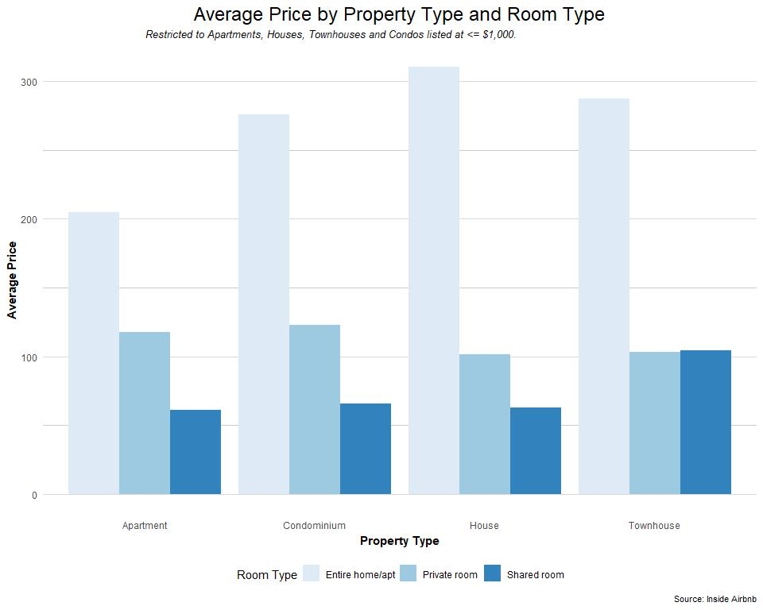

```r
listingsAll%>%
  filter(property_type%in%c("Apartment","Condominium","House","Townhouse"))%>%
  filter(price<=1000)%>%
  group_by(property_type,room_type)%>%
  summarise(avg_price=mean(price,na.rm=T))%>%
  ggplot(aes(x=property_type,y=avg_price))+
  geom_bar(aes(fill=room_type),stat="identity",position="dodge")+
  scale_fill_brewer(palette="Blues")+
  theme_minimal()+
  labs(x = "Property Type", y="Average Price",
       title="Average Price by Property Type and Room Type",
       subtitle="Restricted to Apartments, Houses, Townhouses and Condos listed at <= $1,000.",
       caption="Source: Inside Airbnb",
       fill="Room Type") +
  theme(legend.position = "bottom",
        axis.ticks = element_blank(),
        plot.title = element_text(size=18, hjust=0.5), # Centered Title
        panel.border = element_blank(),
        panel.grid.minor.y = element_line(color="grey80"),
        panel.grid.minor.x = element_blank(),
        panel.grid.major.y = element_line(color="grey85"),
        panel.grid.major.x = element_blank(),
        axis.title = element_text(face="bold"),
        plot.subtitle = element_text(size=10,face="italic",hjust=0.3),
        plot.caption=element_text(size=8))
```

# 2. Scatterplot (8pts)

# Make a scatterplot of price and the accomodates variable to see the

# relationship between price and maximum guests. See Q2_scatterplot.png for the screenshot.

# Filter the Property type by "Apartment", "Condominium", "House", "Townhouse"

# Color the points by the room type

# Use the following colors for the room types: "royalblue", "grey60", "mediumpurple.

# Use size 8 font for the caption and size 10 for the subtitle

# Use alpha = 0.5 for the transparency

# Change the labels on the y-axis to be the character "$1,000", "$2,000", etc.

# Change the breaks on the x-axis

# Use theme_minimal()

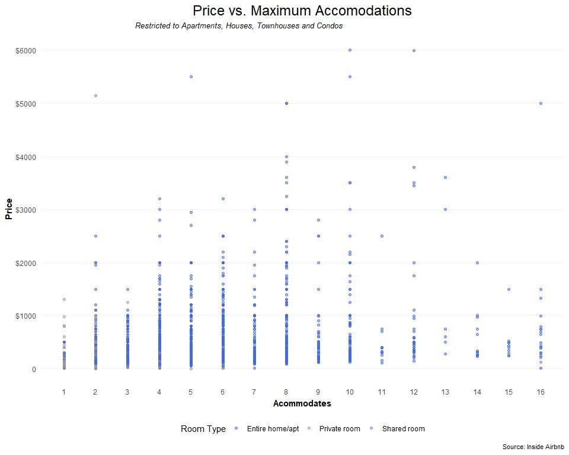

```r
listingsAll%>%
  filter(property_type%in%c("Apartment","Condominium","House","Townhouse"))%>%
  ggplot(aes(x=accommodates,y=price))+
  geom_point(aes(color=room_type),alpha=0.5)+
  scale_color_manual(breaks=c("Entire home/apt","Private room","Shared room"),
                     values=c("royalblue", "grey60", "mediumpurple"))+
  scale_y_continuous(breaks=seq(0,6000,by=1000)
                     ,labels=c("0","$1000","$2000","$3000","$4000","$5000","$6000"))+
  scale_x_continuous(breaks=seq(0,16,by=1))+
  theme_minimal()+
  labs(x = "Acommodates", y="Price",
       title="Price vs. Maximum Accomodations",
       subtitle="Restricted to Apartments, Houses, Townhouses and Condos",
       caption="Source: Inside Airbnb",
       color="Room Type") +
  theme(legend.position = "bottom",
        axis.ticks = element_blank(),
        plot.title = element_text(size=18, hjust=0.5), # Centered Title
        panel.border = element_blank(),
        panel.grid.minor.y = element_blank(),
        panel.grid.minor.x = element_blank(),
        panel.grid.major.y = element_line(color="grey95"),
        panel.grid.major.x = element_blank(),
        axis.title = element_text(face="bold"),
        plot.subtitle = element_text(size=10,face="italic",hjust=0.3),
        plot.caption=element_text(size=8))
```

# 3. Distributions (8pts)

# Compare the distribution of prices for each property type using boxplots.

# There should be a different box for each value of property type, and the points

# should be on the plot as well. See Q3_boxplot.png for the screenshot.

# Filter the Property type by "Apartment", "Condominium", "House", "Townhouse"

# Filter the price <= 1000

# Use the colors "lightsteelblue" and "steelblue" for the boxplot colors and the points respectively

# Make the boxplot transparency 0.5, no outliers

# Make the point transparency 0.05

# Use size 8 font for the caption and size 10 for the subtitle

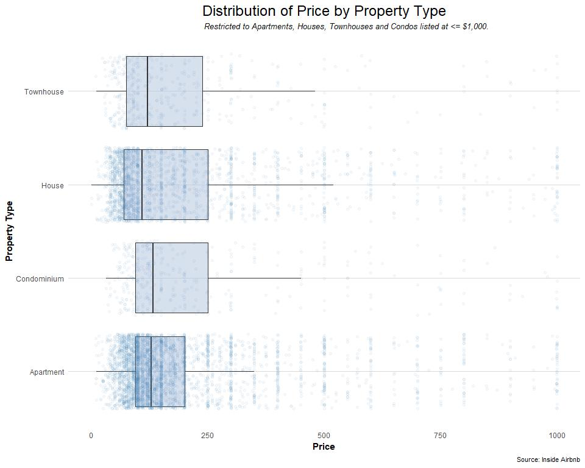

```r
  listingsAll%>%
  filter(property_type%in%c("Apartment","Condominium","House","Townhouse"))%>%
  filter(price<=1000)%>%
  ggplot()+
  coord_flip()+
  geom_boxplot(aes(x=property_type,y=price),fill="lightsteelblue",alpha=0.5,outlier.shape=NA)+
  geom_jitter(aes(x=property_type,y=price),color="steelblue",alpha=0.05)+
  theme_bw()+
  theme(legend.position = "bottom",
        axis.ticks = element_blank(),
        plot.title = element_text(size=18, hjust=0.5),
        panel.border = element_blank(),
        panel.grid.minor.y = element_line(color="grey80"),
        panel.grid.minor.x = element_blank(),
        panel.grid.major.y = element_line(color="grey85"),
        panel.grid.major.x = element_blank(),
        axis.title = element_text(face="bold"),
        plot.subtitle = element_text(size=10,face="italic",hjust=0.6),
        plot.caption=element_text(size=8))+
  labs(x = "Property Type", y="Price",
       title="Distribution of Price by Property Type",
       subtitle="Restricted to Apartments, Houses, Townhouses and Condos listed at <= $1,000.",
       caption="Source: Inside Airbnb")
```

# 4. Heatmap (8pts)

# Compare the number of listings of each property type and room type

# using a heatmap. See Q4_heatmap.png for the screenshot.

# Use the colors "white" and "royalblue" as the low and high values

# Use size 8 font for the caption and size 10 for the subtitle

# Place the legend on the right-hand side

# Reorder the y-axis by the total number of listings

# Remove NAs

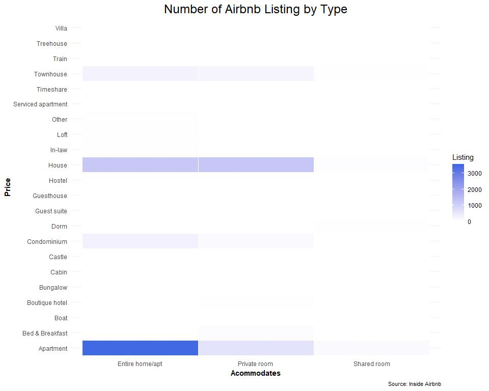

```r
listingsAll%>%
  group_by(property_type,room_type)%>%
  count()%>%
  #na.omit()%>%
  complete(room_type,property_type, fill = list(n = 0))%>%
  ggplot(aes(x=room_type,y=property_type))+
  geom_tile(aes(fill=n),color="white")+
  scale_fill_continuous("Listing",
                        low="white", high="royalblue")+
  theme_minimal()+
  labs(x = "Acommodates", y="Price",
       title="Number of Airbnb Listing by Type",
       caption="Source: Inside Airbnb",
       fill="Listings") +
  theme(
        axis.ticks = element_blank(),
        plot.title = element_text(size=18, hjust=0.5), # Centered Title
        panel.border = element_blank(),
        panel.grid.minor.y = element_blank(),
        panel.grid.minor.x = element_blank(),
        panel.grid.major.y = element_line(color="grey95"),
        panel.grid.major.x = element_blank(),
        axis.title = element_text(face="bold"),
        plot.subtitle = element_text(size=10,face="italic",hjust=0.3),
        plot.caption=element_text(size=8))
```

# 5. Insight (8pts)

# The following question asks you to come up with one insight on specific

# elements of the Airbnb data. This chart will be graded according to the following dimensions:

# Is the chart technically correct? - 4 pts

# Does it contain data errors?

# Does it contain the appropriate elements?

# Is your conclusion sound? - 2pt

# Is the graph attractive? - 1pt

# How sophisticated is your graph? - 1pt

# Prompt:

# I am considering listing a 1-bed, 1-bath property on Airbnb, and I

# want to know what elements of the listing are associated with high

# reviews. Tell me something useful about the relationship between

# review score and price, cleaning_fee, guests, extra people,

# max accommodations, room type, bed type and/or neighborhood.

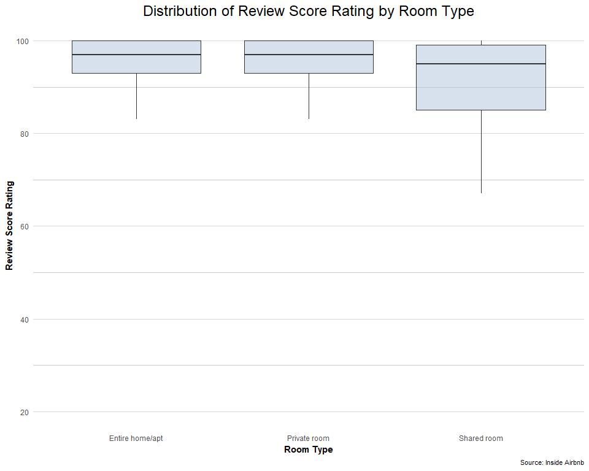

```r
listingsAll%>%
  ggplot(aes(x=room_type,y=review_scores_rating))+
  geom_boxplot(fill="lightsteelblue",alpha=0.5,outlier.shape=NA)+
  theme_bw()+
  theme(legend.position = "bottom",
        axis.ticks = element_blank(),
        plot.title = element_text(size=18, hjust=0.5),
        panel.border = element_blank(),
        panel.grid.minor.y = element_line(color="grey80"),
        panel.grid.minor.x = element_blank(),
        panel.grid.major.y = element_line(color="grey85"),
        panel.grid.major.x = element_blank(),
        axis.title = element_text(face="bold"),
        plot.subtitle = element_text(size=10,face="italic",hjust=0.6),
        plot.caption=element_text(size=8))+
  labs(x = "Room Type", y="Review Score Rating",
       title="Distribution of Review Score Rating by Room Type",
       caption="Source: Inside Airbnb")
```

# shared room's review is lower than the other two